# Ag Yield Prediction - VAR

Step 0) read in Corn, Soy, and Wheat data for Minnesota:

```r
ag_df_all = read_csv("../data/MN_Ag_YieldsAndInputs.csv") %>% arrange(Year)
# bedd_and_precip = read_csv("../data/CMIP5_Agro_year.csv", col_names = FALSE)
# colnames(bedd_and_precip) = c('idx', 'value', 'year', 'variable', 'scenario')
# bedd_and_precip = bedd_and_precip %>%
#   pivot_wider(names_from = variable, values_from = value)
```

```r
ag_df = ag_df_all[!is.na(ag_df_all$Soy_BUperAcre),]
head(ag_df)
```

```
## # A tibble: 6 x 16
##    Year Corn_BUperAcre Wheat_BUperAcre Soy_BUperAcre Corn_NITROGEN
##   <dbl>          <dbl>           <dbl>         <dbl>         <dbl>
## 1  1934           24.6            10.6          15              NA
## 2  1935           34.5             9.5          14              NA
## 3  1936           22               9            12              NA
## 4  1937           37.5            16            14              NA
## 5  1938           36.5            15            15              NA
## 6  1939           47              13.2          16.8            NA
## # … with 11 more variables: Corn_PHOSPHATE <dbl>, Corn_POTASH <dbl>,
## #   Corn_SULFUR <dbl>, Wheat_NITROGEN <dbl>, Wheat_PHOSPHATE <dbl>,
## #   Wheat_POTASH <dbl>, Wheat_SULFUR <dbl>, Soy_NITROGEN <dbl>,
## #   Soy_PHOSPHATE <dbl>, Soy_POTASH <dbl>, Soy_SULFUR <dbl>
```

As we can see here, we don’t have fertilizer input information for each year of data. We can use a spline approach to interpolate the missing values, but this will be trickier for the newer values as we don’t have data on either side and we’re essentially forecasting things that already happened.

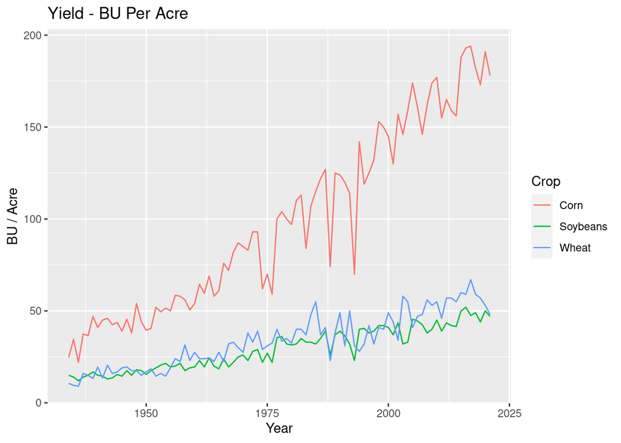

```r
ag_plot = ag_df %>% pivot_longer(cols = ends_with('BUperAcre'))
ggplot(ag_plot, aes(x = Year, y = value, col = name)) +
    geom_line() +
    ggtitle('Yield - BU Per Acre') +
    scale_color_discrete(name = 'Crop', labels = c('Corn', 'Soybeans', 'Wheat')) +
    ylab('BU / Acre')
```

Our data look a bit heteroskedastic - especially in the down years. Let’s use a box cox transformation and see if we can make an improvement.

```r
ag_yields = ag_df[,1:4]
BoxCox.lambda(ts(ag_yields[,2:4]))
```

```
## [1] 0.04355743
```

This is pretty close to a straight log transformation.

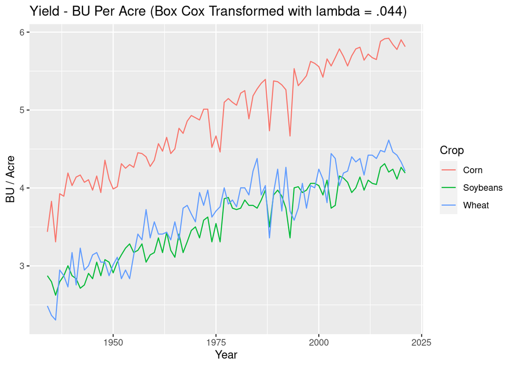

```r
ag_plot = ag_df[,2:4] %>%
    BoxCox(0.04355743) %>%
    cbind(Year = ag_df[,1]) %>%
    pivot_longer(cols = ends_with('BUperAcre'))

ggplot(ag_plot, aes(x = Year, y = value, col = name)) +
    geom_line() +
    ggtitle('Yield - BU Per Acre (Box Cox Transformed with lambda = .044)') +
    scale_color_discrete(name = 'Crop', labels = c('Corn', 'Soybeans', 'Wheat')) +
    ylab('BU / Acre')
```

This makes the perturbations look a bit less extreme - we will go with this moving forward.

```r
ag_lambda = 0.04355743

ag_transformed = ag_df[,2:4] %>%
    BoxCox(0.04355743) %>%
    cbind(Year = ag_df[,1])

lead_years = 5
mae_df = data.frame()
aicc_df = data.frame()

for (p_lag in 5:1) {

    for (idx in 40:(nrow(ag_transformed) - 1)){
      #increase iteration number
      it_number = idx - 39

      test_ts = ag_transformed[(idx + 1):(idx + lead_years), 1:3]

      train_expand = ag_transformed[1:idx, 1:3] %>% ts()
      train_slide = ag_transformed[(idx - 39):idx, 1:3] %>% ts()

      # VAR Expanding
      m1 = VAR(train_expand, p = p_lag, type = 'both')
      f1 = forecast(m1, h=lead_years)

      mae_corn = abs(f1$forecast$Corn_BUperAcre$mean - test_ts$Corn_BUperAcre)
      mae_wheat = abs(f1$forecast$Wheat_BUperAcre$mean - test_ts$Wheat_BUperAcre)
      mae_soy = abs(f1$forecast$Soy_BUperAcre$mean - test_ts$Soy_BUperAcre)

      newlines = data.frame(mae_corn, mae_wheat, mae_soy) %>%
          t() %>%
          cbind(data.frame(model = 'Expanding VAR',
                           crop = c('Corn', 'Wheat', 'Soy'),
                           n_train = nrow(train_expand),
                           lag_order = p_lag))

      mae_df = bind_rows(mae_df, newlines)

      # VAR Sliding
      m2 = VAR(train_slide, p = p_lag, type = 'both')
      f2 = forecast(m2, h=lead_years)

      mae_corn = abs(f2$forecast$Corn_BUperAcre$mean - test_ts$Corn_BUperAcre)
      mae_wheat = abs(f2$forecast$Wheat_BUperAcre$mean - test_ts$Wheat_BUperAcre)
      mae_soy = abs(f2$forecast$Soy_BUperAcre$mean - test_ts$Soy_BUperAcre)

      newlines = data.frame(mae_corn, mae_wheat, mae_soy) %>%
          t() %>%
          cbind(data.frame(model = 'Sliding VAR',
                           crop = c('Corn', 'Wheat', 'Soy'),
                           n_train = nrow(train_slide),
                           lag_order = p_lag))

      mae_df = bind_rows(mae_df, newlines)
    }
}
```

```r
rownames(mae_df) = 1:nrow(mae_df)
plot_mae = pivot_longer(mae_df, cols = -c('model', 'crop', 'lag_order', 'n_train')) %>%
    rename(horizon = name,
           abs_error = value) %>%
    mutate(horizon = as.integer(horizon))
```

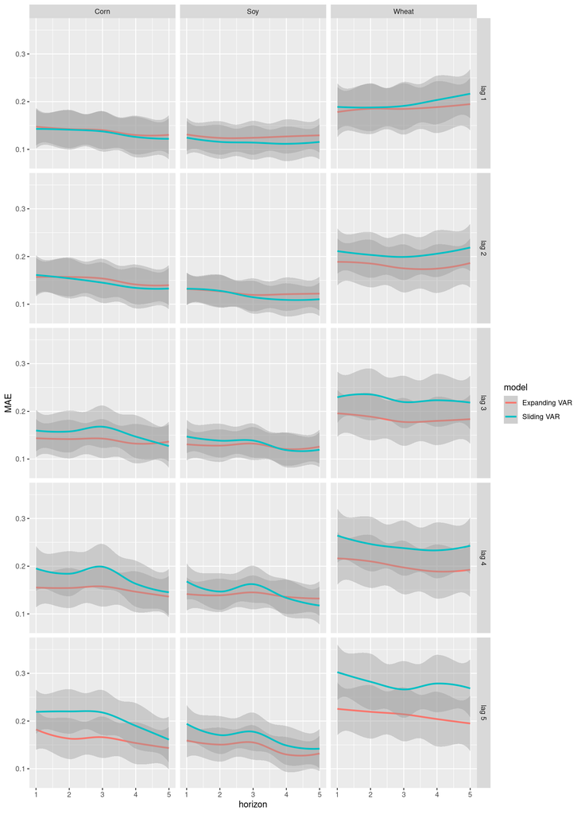

```r
ggplot(plot_mae, aes(x = horizon, y = abs_error, col=model)) +
  facet_grid(paste0('lag ', lag_order)~crop) +
  geom_smooth() +
  ylab('MAE')
```

## Comparison with other models

- 5 leads
- 5 lags (sliding)
- BoxCox lambda of 0 - log transformation, as it’s pretty close to 0 anyways and it helps with interpretability
- mean percent error for each lead to facilitate comparison between different crops

```r
ag_lambda = 0

ag_transformed = ag_df[,2:4] %>%
    BoxCox(0) %>%
    cbind(Year = ag_df[,1])

lead_years = 5
window_len = 60
p_lag = 5
ape_df = data.frame()

for (idx in window_len:(nrow(ag_transformed) - 1)){
    test_ts = ag_transformed[(idx + 1):(idx + lead_years), 1:3]
    train_slide = ag_transformed[(idx - window_len):idx, 1:3] %>% ts()

    # VAR Sliding
    m2 = VAR(train_slide, p = p_lag, type = 'both')
    f2 = forecast(m2, h=lead_years)
    year = max(ag_transformed[(idx - window_len):idx, 'Year'])

    ape_corn = abs(f2$forecast$Corn_BUperAcre$mean - test_ts$Corn_BUperAcre) / test_ts$Corn_BUperAcre
    ape_wheat = abs(f2$forecast$Wheat_BUperAcre$mean - test_ts$Wheat_BUperAcre) / test_ts$Wheat_BUperAcre
    ape_soy = abs(f2$forecast$Soy_BUperAcre$mean - test_ts$Soy_BUperAcre) / test_ts$Soy_BUperAcre

    forecasts = data.frame(f2$forecast$Corn_BUperAcre$mean,
                           f2$forecast$Wheat_BUperAcre$mean,
                           f2$forecast$Soy_BUperAcre$mean) %>% t()

    colnames(forecasts) = paste('VAR3_t+', 1:5, sep='')

    newlines = data.frame(ape_corn, ape_wheat, ape_soy, row.names = paste('APE_', 1:5, sep='')) %>%
        t() %>%
        cbind(forecasts) %>%
        cbind(data.frame(model = 'VAR3',
                         crop = c('corn', 'wheat', 'soy'),
                         year = year))

    ape_df = bind_rows(ape_df, newlines)
}
rownames(ape_df) = 1:nrow(ape_df)
kable(ape_df, digits = 3)
```

| APE_1 | APE_2 | APE_3 | APE_4 | APE_5 | VAR3_t+1 | VAR3_t+2 | VAR3_t+3 | VAR3_t+4 | VAR3_t+5 | model | crop | year |
| --- | --- | --- | --- | --- | --- | --- | --- | --- | --- | --- | --- | --- |
| 0.031 | 0.017 | 0.018 | 0.009 | 0.049 | 4.804 | 4.698 | 4.913 | 4.928 | 4.784 | VAR3 | corn | 1993 |
| 0.158 | 0.105 | 0.028 | 0.117 | 0.025 | 3.858 | 3.831 | 3.635 | 3.872 | 3.622 | VAR3 | wheat | 1993 |
| 0.026 | 0.047 | 0.014 | 0.004 | 0.069 | 3.592 | 3.528 | 3.690 | 3.679 | 3.480 | VAR3 | soy | 1993 |
| 0.014 | 0.006 | 0.023 | 0.056 | 0.009 | 4.714 | 4.858 | 4.996 | 4.749 | 5.056 | VAR3 | corn | 1994 |
| 0.065 | 0.137 | 0.086 | 0.022 | 0.003 | 3.691 | 3.226 | 3.765 | 3.633 | 3.700 | VAR3 | wheat | 1994 |
| 0.064 | 0.013 | 0.009 | 0.097 | 0.010 | 3.463 | 3.683 | 3.698 | 3.376 | 3.701 | VAR3 | soy | 1994 |
| 0.020 | 0.011 | 0.050 | 0.007 | 0.032 | 4.730 | 4.935 | 4.781 | 5.045 | 4.819 | VAR3 | corn | 1995 |
| 0.156 | 0.079 | 0.023 | 0.016 | 0.038 | 3.155 | 3.740 | 3.627 | 3.747 | 3.743 | VAR3 | wheat | 1995 |
| 0.016 | 0.027 | 0.061 | 0.005 | 0.032 | 3.697 | 3.763 | 3.509 | 3.756 | 3.596 | VAR3 | soy | 1995 |
| 0.035 | 0.018 | 0.013 | 0.037 | 0.006 | 5.052 | 4.942 | 4.945 | 4.795 | 4.899 | VAR3 | corn | 1996 |
| 0.137 | 0.043 | 0.049 | 0.048 | 0.013 | 3.940 | 3.874 | 3.869 | 3.704 | 3.834 | VAR3 | wheat | 1996 |
| 0.034 | 0.064 | 0.032 | 0.041 | 0.001 | 3.788 | 3.500 | 3.620 | 3.562 | 3.616 | VAR3 | soy | 1996 |
| 0.032 | 0.030 | 0.025 | 0.008 | 0.025 | 4.869 | 4.859 | 4.854 | 4.905 | 4.928 | VAR3 | corn | 1997 |
| 0.001 | 0.018 | 0.077 | 0.001 | 0.052 | 3.718 | 3.621 | 3.591 | 3.780 | 3.710 | VAR3 | wheat | 1997 |
| 0.081 | 0.030 | 0.029 | 0.003 | 0.034 | 3.436 | 3.625 | 3.606 | 3.599 | 3.645 | VAR3 | soy | 1997 |
| 0.053 | 0.023 | 0.016 | 0.021 | 0.005 | 4.746 | 4.861 | 4.944 | 4.949 | 5.007 | VAR3 | corn | 1998 |
| 0.004 | 0.044 | 0.017 | 0.074 | 0.066 | 3.675 | 3.722 | 3.850 | 3.786 | 3.793 | VAR3 | wheat | 1998 |
| 0.031 | 0.019 | 0.025 | 0.015 | 0.093 | 3.622 | 3.642 | 3.701 | 3.717 | 3.788 | VAR3 | soy | 1998 |
| 0.000 | 0.025 | 0.017 | 0.013 | 0.009 | 4.976 | 4.987 | 4.971 | 5.050 | 5.023 | VAR3 | corn | 1999 |
| 0.032 | 0.022 | 0.093 | 0.038 | 0.029 | 3.769 | 3.866 | 3.853 | 3.906 | 3.890 | VAR3 | wheat | 1999 |
| 0.008 | 0.021 | 0.023 | 0.084 | 0.072 | 3.684 | 3.687 | 3.684 | 3.758 | 3.748 | VAR3 | soy | 1999 |
| 0.018 | 0.012 | 0.009 | 0.009 | 0.016 | 4.954 | 4.996 | 5.028 | 5.025 | 5.078 | VAR3 | corn | 2000 |
| 0.028 | 0.113 | 0.033 | 0.029 | 0.054 | 3.892 | 3.925 | 3.926 | 3.889 | 3.914 | VAR3 | wheat | 2000 |
| 0.017 | 0.019 | 0.084 | 0.076 | 0.006 | 3.673 | 3.701 | 3.755 | 3.762 | 3.795 | VAR3 | soy | 2000 |
| 0.014 | 0.002 | 0.005 | 0.016 | 0.001 | 4.987 | 4.994 | 5.045 | 5.075 | 5.084 | VAR3 | corn | 2001 |
| 0.101 | 0.049 | 0.039 | 0.045 | 0.003 | 3.883 | 3.862 | 3.850 | 3.879 | 3.862 | VAR3 | wheat | 2001 |
| 0.019 | 0.081 | 0.081 | 0.005 | 0.001 | 3.699 | 3.747 | 3.780 | 3.797 | 3.791 | VAR3 | soy | 2001 |
| 0.009 | 0.020 | 0.004 | 0.003 | 0.028 | 5.029 | 4.968 | 5.140 | 5.096 | 5.125 | VAR3 | corn | 2002 |
| 0.064 | 0.069 | 0.037 | 0.010 | 0.008 | 3.800 | 3.732 | 3.850 | 3.888 | 3.842 | VAR3 | wheat | 2002 |
| 0.094 | 0.074 | 0.008 | 0.000 | 0.024 | 3.791 | 3.755 | 3.848 | 3.796 | 3.839 | VAR3 | soy | 2002 |

[output cut: 54 more lines]

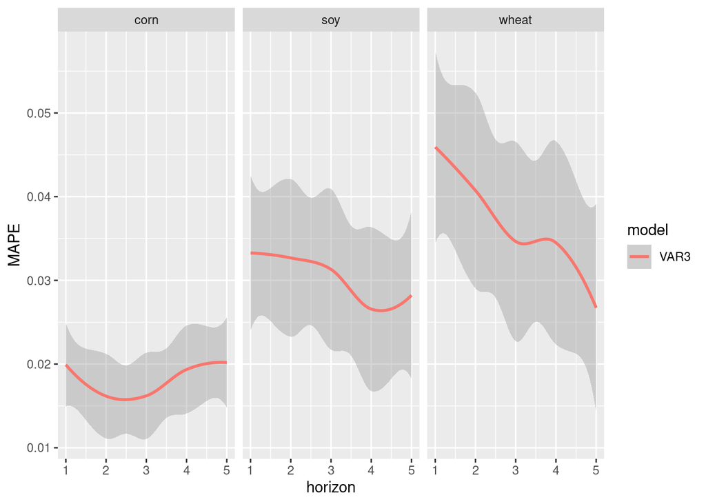

```r
plot_ape = pivot_longer(ape_df, cols = -c('model', 'crop', paste('VAR3_t+', 1:5, sep=''))) %>%
    rename(horizon = name,
           abs_error = value) %>%
    mutate(horizon = as.integer(str_sub(horizon, -1)))
ggplot(plot_ape, aes(x = horizon, y = abs_error, col=model)) +
  facet_grid(.~crop) +
  geom_smooth() +
  ylab('MAPE')
```

```r
ag_lambda = 0
ag_df = ag_df_all[!is.na(ag_df_all$Wheat_BUperAcre),]

ag_transformed = ag_df[,2:4] %>%
    BoxCox(0) %>%
    cbind(Year = ag_df[,1])

lead_years = 5
window_len = 60
p_lag = 5
ape_df2 = data.frame()

for (idx in window_len:(nrow(ag_transformed) - 1)){
    test_ts = ag_transformed[(idx + 1):(idx + lead_years), 1:2]
    train_slide = ag_transformed[(idx - window_len):idx, 1:2] %>% ts()
    year = max(ag_transformed[(idx - window_len):idx, 'Year'])

    # VAR Sliding
    m2 = VAR(train_slide, p = p_lag, type = 'both')
    f2 = forecast(m2, h=lead_years)

    ape_corn = abs(f2$forecast$Corn_BUperAcre$mean - test_ts$Corn_BUperAcre) / test_ts$Corn_BUperAcre
    ape_wheat = abs(f2$forecast$Wheat_BUperAcre$mean - test_ts$Wheat_BUperAcre) / test_ts$Wheat_BUperAcre

    forecasts = data.frame(f2$forecast$Corn_BUperAcre$mean,
                           f2$forecast$Wheat_BUperAcre$mean) %>% t()

    colnames(forecasts) = paste('VARcw_t+', 1:5, sep='')

    newlines = data.frame(ape_corn, ape_wheat, row.names = paste('APE_', 1:5, sep='')) %>%
        t() %>%
        cbind(forecasts) %>%
        cbind(data.frame(model = 'VARcw',
                         crop = c('corn', 'wheat'),
                         year = year))

    ape_df2 = bind_rows(ape_df2, newlines)
}
rownames(ape_df2) = 1:nrow(ape_df2)
kable(ape_df2, digits = 3)
```

| APE_1 | APE_2 | APE_3 | APE_4 | APE_5 | VARcw_t+1 | VARcw_t+2 | VARcw_t+3 | VARcw_t+4 | VARcw_t+5 | model | crop | year |
| --- | --- | --- | --- | --- | --- | --- | --- | --- | --- | --- | --- | --- |
| 0.007 | 0.009 | 0.044 | 0.045 | 0.038 | 4.636 | 4.532 | 4.492 | 4.513 | 4.598 | VARcw | corn | 1978 |
| 0.028 | 0.030 | 0.038 | 0.039 | 0.051 | 3.456 | 3.587 | 3.549 | 3.833 | 3.794 | VARcw | wheat | 1978 |
| 0.002 | 0.042 | 0.045 | 0.037 | 0.002 | 4.565 | 4.503 | 4.513 | 4.593 | 4.663 | VARcw | corn | 1979 |
| 0.036 | 0.035 | 0.031 | 0.044 | 0.024 | 3.607 | 3.558 | 3.805 | 3.770 | 3.778 | VARcw | wheat | 1979 |
| 0.052 | 0.049 | 0.035 | 0.004 | 0.015 | 4.457 | 4.495 | 4.584 | 4.656 | 4.675 | VARcw | corn | 1980 |
| 0.043 | 0.016 | 0.042 | 0.021 | 0.063 | 3.532 | 3.750 | 3.764 | 3.790 | 3.753 | VARcw | wheat | 1980 |
| 0.033 | 0.056 | 0.001 | 0.013 | 0.026 | 4.573 | 4.679 | 4.670 | 4.681 | 4.680 | VARcw | corn | 1981 |
| 0.028 | 0.082 | 0.003 | 0.052 | 0.052 | 3.794 | 3.908 | 3.861 | 3.799 | 3.798 | VARcw | wheat | 1981 |
| 0.056 | 0.007 | 0.010 | 0.023 | 0.027 | 4.677 | 4.704 | 4.696 | 4.691 | 4.713 | VARcw | corn | 1982 |
| 0.073 | 0.005 | 0.036 | 0.069 | 0.030 | 3.875 | 3.890 | 3.863 | 3.860 | 3.824 | VARcw | wheat | 1982 |
| 0.017 | 0.034 | 0.030 | 0.031 | 0.105 | 4.591 | 4.581 | 4.660 | 4.694 | 4.757 | VARcw | corn | 1983 |
| 0.013 | 0.080 | 0.045 | 0.014 | 0.184 | 3.821 | 3.685 | 3.772 | 3.767 | 3.712 | VARcw | wheat | 1983 |
| 0.028 | 0.021 | 0.028 | 0.107 | 0.016 | 4.612 | 4.705 | 4.710 | 4.763 | 4.749 | VARcw | corn | 1984 |
| 0.076 | 0.060 | 0.023 | 0.192 | 0.057 | 3.702 | 3.828 | 3.801 | 3.737 | 3.843 | VARcw | wheat | 1984 |
| 0.001 | 0.011 | 0.107 | 0.021 | 0.017 | 4.810 | 4.793 | 4.764 | 4.726 | 4.736 | VARcw | corn | 1985 |
| 0.078 | 0.062 | 0.205 | 0.053 | 0.012 | 3.891 | 3.944 | 3.779 | 3.831 | 3.844 | VARcw | wheat | 1985 |
| 0.028 | 0.101 | 0.016 | 0.012 | 0.009 | 4.710 | 4.740 | 4.749 | 4.762 | 4.832 | VARcw | corn | 1986 |
| 0.052 | 0.190 | 0.053 | 0.001 | 0.146 | 3.908 | 3.730 | 3.829 | 3.887 | 3.935 | VARcw | wheat | 1986 |
| 0.078 | 0.019 | 0.011 | 0.010 | 0.037 | 4.638 | 4.737 | 4.766 | 4.835 | 4.912 | VARcw | corn | 1987 |
| 0.176 | 0.046 | 0.006 | 0.157 | 0.026 | 3.687 | 3.805 | 3.914 | 3.973 | 4.012 | VARcw | wheat | 1987 |
| 0.061 | 0.042 | 0.023 | 0.061 | 0.170 | 4.535 | 4.616 | 4.895 | 5.027 | 4.970 | VARcw | corn | 1988 |
| 0.033 | 0.048 | 0.148 | 0.036 | 0.129 | 3.757 | 3.704 | 3.943 | 4.053 | 3.878 | VARcw | wheat | 1988 |
| 0.056 | 0.044 | 0.055 | 0.176 | 0.013 | 4.552 | 4.998 | 4.995 | 4.997 | 5.018 | VARcw | corn | 1989 |
| 0.075 | 0.129 | 0.040 | 0.142 | 0.243 | 3.601 | 3.876 | 4.070 | 3.921 | 4.142 | VARcw | wheat | 1989 |
| 0.064 | 0.073 | 0.155 | 0.005 | 0.007 | 5.092 | 5.081 | 4.906 | 4.931 | 4.815 | VARcw | corn | 1990 |
| 0.136 | 0.074 | 0.154 | 0.240 | 0.164 | 3.902 | 4.202 | 3.963 | 4.131 | 4.035 | VARcw | wheat | 1990 |
| 0.050 | 0.131 | 0.005 | 0.024 | 0.020 | 4.972 | 4.806 | 4.983 | 4.894 | 4.923 | VARcw | corn | 1991 |
| 0.065 | 0.091 | 0.195 | 0.179 | 0.027 | 4.167 | 3.748 | 3.983 | 4.085 | 3.838 | VARcw | wheat | 1991 |
| 0.118 | 0.011 | 0.021 | 0.015 | 0.010 | 4.749 | 4.902 | 4.882 | 4.901 | 4.934 | VARcw | corn | 1992 |
| 0.094 | 0.172 | 0.141 | 0.028 | 0.142 | 3.756 | 3.904 | 3.954 | 3.841 | 3.958 | VARcw | wheat | 1992 |

[output cut: 56 more lines]

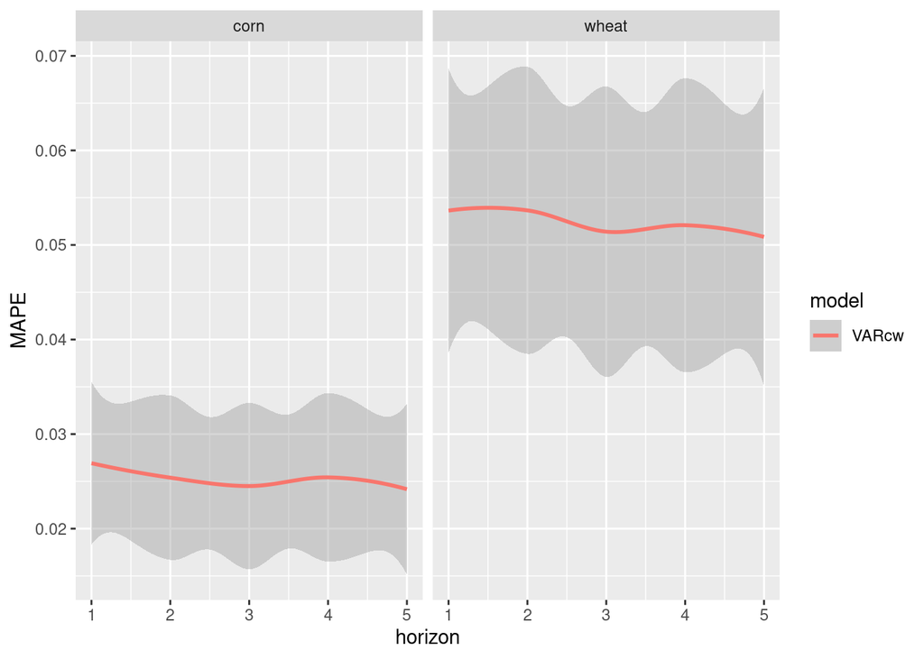

```r
plot_ape = pivot_longer(ape_df2, cols = -c('model', 'crop', paste('VARcw_t+', 1:5, sep=''))) %>%
    rename(horizon = name,
           abs_error = value) %>%
    mutate(horizon = as.integer(str_sub(horizon, -1)))
ggplot(plot_ape, aes(x = horizon, y = abs_error, col=model)) +
  facet_grid(.~crop) +
  geom_smooth() +
  ylab('MAPE')
```

```r
df_out = ape_df2 %>% dplyr::select(starts_with('VARcw_t+'), year, crop) %>%
  full_join(ape_df %>% dplyr::select(starts_with('VAR3_t+'), year, crop)) %>%
  mutate_at(vars(starts_with('VAR')), exp) %>%
  arrange(crop)
df_out %>% write.csv('../data/VAR_predictions.csv')
```